# Visualization

```
##   carat clarity color       cut price
## 1  0.51     SI2     I Very Good   774
## 2  0.93      IF     H     Ideal  6246
## 3  0.50    VVS2     D Very Good  1146
## 4  0.30     VS1     F     Ideal   538
## 5  0.31     SI1     F     Ideal   502
```

```
## [1] 0
```

```
##   carat clarity color       cut price price_group clarity_group    color_group
## 1  0.51     SI2     I Very Good   774          50            SI Near-Colorless
## 2  0.93      IF     H     Ideal  6246         100            IF Near-Colorless
## 3  0.50    VVS2     D Very Good  1146          50           VVS      Colorless
## 4  0.30     VS1     F     Ideal   538          25            VS      Colorless
## 5  0.31     SI1     F     Ideal   502          25            SI      Colorless
```

## Part 1: Checking Distribution

** 1. On Clarity **

To start with, let's look at the number of diamonds across all clarity groups. Clarity groups are ordered in terms of their values in descending order. As we predicted, lower clarity diamonds are more prevalent in this data.

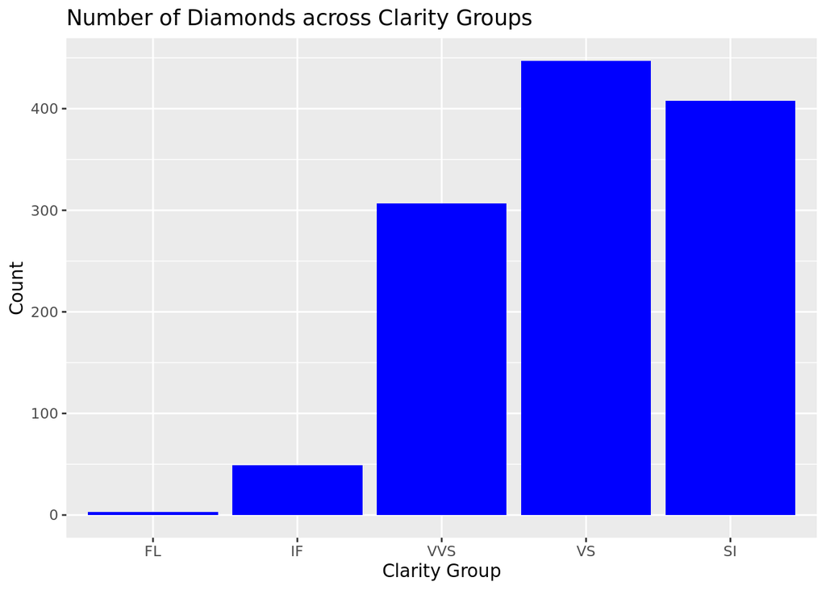

Now, let's take a look at the boxplot of clarity group associated with price. FL, the one with highest clarity overall had higher median prices. What's interesting is that data points with high prices were found in VVS and VS group, not from IF groups. Although IF group is presumed to have higher prices than rest of the groups, turns out that VVS and VS groups had higher prices. However, it is hasty to judge that clarity is not a determining factor of price. We will delve into this more.

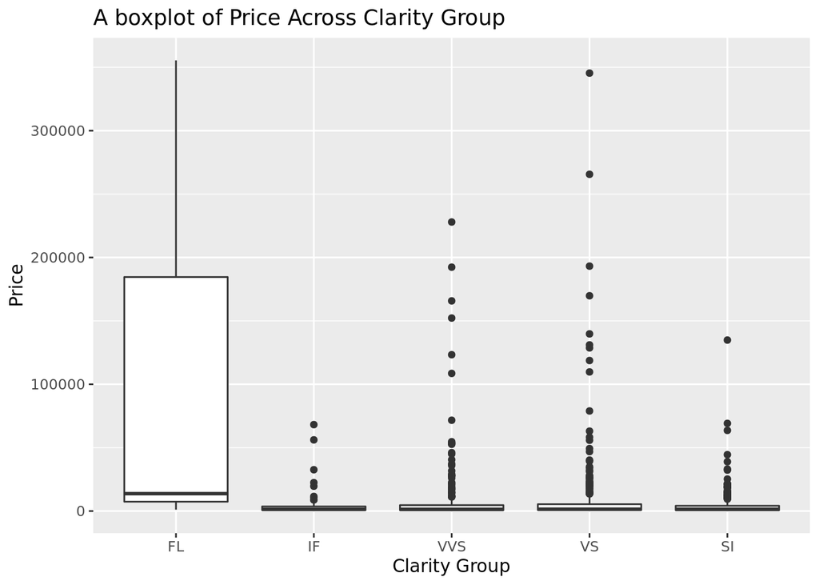

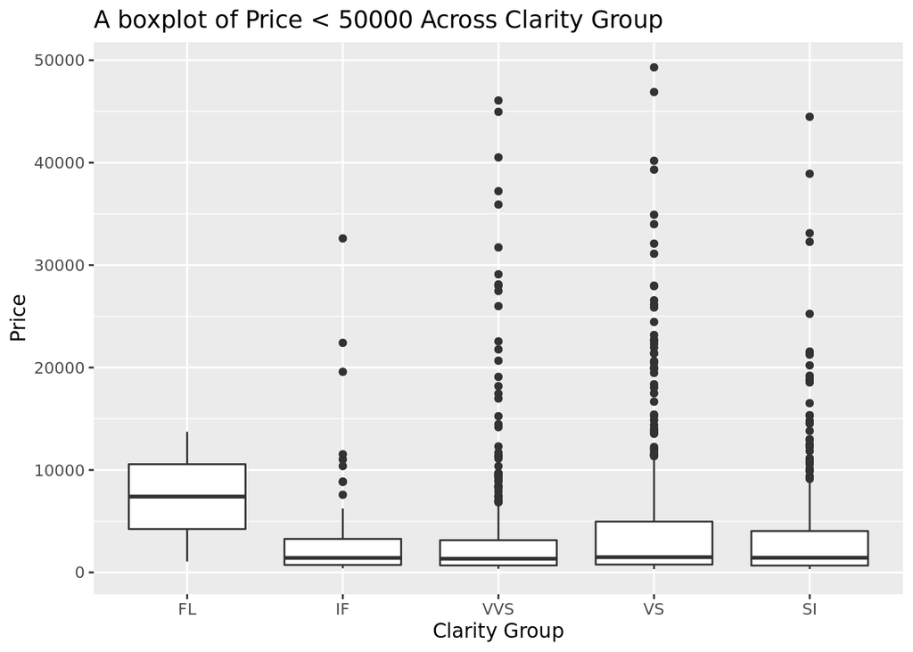

In order to take a closer look on numerical data, we group by clarity and check mean and median values. Due to outliers, across all groups, there are large discrepancies between mean and median prices. When it comes to median price, FL had the highest median price, then VS, SI, IF, and VVS. However, as we have only 3 observations and huge standard deviation on FL group, it is difficult to definitely trust the result of mean and median price of FL group as it is. When we use summarize function on reduced dataset with price < 50,000, FL had the highest median price, then VS, SI, IF, and VVS, same result. In short, from these summarized datframes, we can deduce **higher clarity does not necessarily guarantee higher median price.**

```
## # A tibble: 5 × 5
##   clarity_group count mean_price median_price      sd
##   <chr>         <int>      <dbl>        <dbl>   <dbl>
## 1 FL                3    123403.        13733 201018.
## 2 IF               49      6362.         1427  13287.
## 3 SI              408      4084.         1446   9489.
## 4 VS              447      8431.         1520  28048.
## 5 VVS             307      7981.         1392  24501.
```

```
## # A tibble: 5 × 5
##   clarity_group count mean_price median_price    sd
##   <chr>         <int>      <dbl>        <dbl> <dbl>
## 1 FL                2      7402.        7402. 8953.
## 2 IF               47      3988.        1419  6443.
## 3 SI              405      3453.        1436  5360.
## 4 VS              434      4403.        1489  7149.
## 5 VVS             296      4034.        1340. 7182.
```